# Notebook

**Research Question:** "For signal strength (judgement ⑧) — a subjective ordinal call (weak/moderate/strong) — how self-consistent is each model, how much do the models agree with each other, and do they track the human coder (Polina)?"

*Judgement ⑧ of 11 · subjective family: no right answer, so the axis is consistency (Krippendorff's ordinal alpha), not accuracy. Sentiment (⑦) is analysed separately.*

**Abstract.** Signal strength (⑧) — how *strong* a report is — is subjective and ordinal, so we measure consistency, not accuracy, across **22 models** on the Polina-labelled pairs (k=3, temp 0), using ordinal Krippendorff's α (a weak-vs-strong miss counts more than weak-vs-moderate). **Within-model** self- agreement is high (median α **0.90**). But **cross-model** agreement is the lowest of any judgement in the pipeline: panel α **0.59** — models genuinely disagree on *how strong* a report is, even when they agree on its direction. Against **Polina** the median is **0.37**. The reading: signal is **intrinsically underdetermined** from short posts, which caps how much any downstream weighting by signal strength can be trusted — and, as everywhere in the subjective family, agreement here is a diagnostic, not a verdict.

## 1. Why signal is measured by consistency, not accuracy

Signal strength (weak / moderate / strong) rates how emphatic a report is — an interpretive, ordinal call with no external truth. So we measure consistency with **ordinal** Krippendorff's α (unlike sentiment's nominal α, an ordinal metric treats weak-vs-strong as a bigger miss than weak-vs-moderate): does a model agree with **itself**, the **other models**, and the **human**? The governing caveat is the same — agreement is a diagnostic of how underdetermined the call is, not proof anyone is right.

## 2. Within-model consistency at temperature 0

Each model against itself across the K repeats. High = stable; low = the model itself can't reproduce its own strength rating.

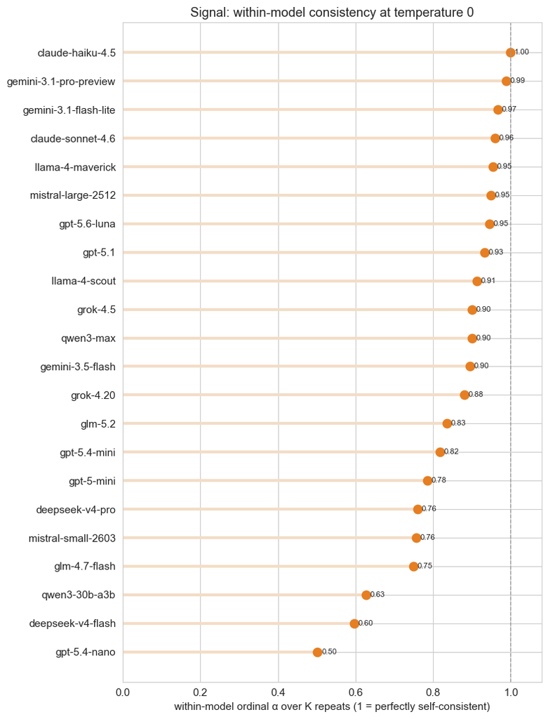

**What this shows:** within-model ordinal α is high (median **0.90**) — a model reproduces its own strength call at temperature 0. So the disagreement in §3 is real between-model divergence, not noise.

## 3. Cross-model agreement — the least-agreed judgement

The models against each other. Pairwise ordinal α heatmap + the panel α. Expect this to be the lowest in the pipeline: rating *strength* from a short post is genuinely underdetermined.

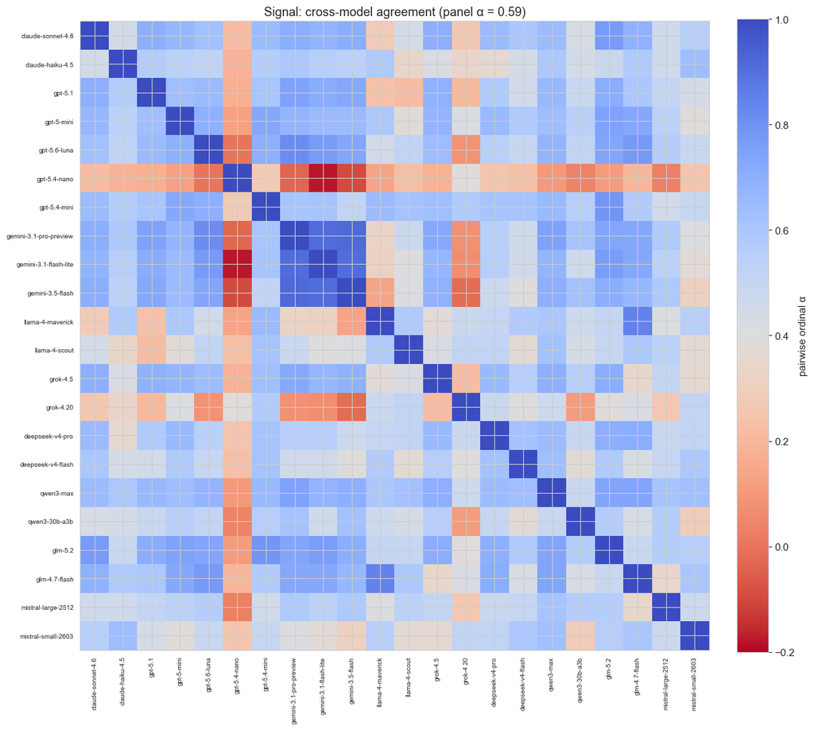

**What this shows:** panel ordinal α **0.59** — the lowest cross-model agreement of any judgement tested. Models concur on a report's *direction* far more than its *strength*. Biggest outlier **gpt-5.4-nano** (1 − mean pairwise 0.86). Low agreement here isn't a model failure so much as a property of the task: weak/moderate/strong is a fuzzy line on a 100–800-char post.

## 4. Agreement with the human coder (Polina)

Each model vs Polina's signal labels — a **screen**, not a ranking (her codebook came from the same prompt).

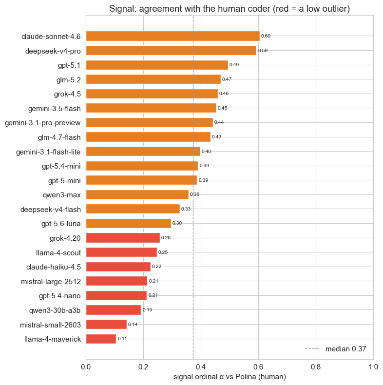

**What this shows:** vs-Polina signal α clusters low around **0.37** — even the human is only loosely tracked, best **claude-sonnet-4.6** (0.60). Consistent with §3: strength is the call humans and models alike find hardest to pin down, so vs-Polina here mostly confirms the task is fuzzy, not that any model is right.

## 5. What low signal-agreement means for the pipeline

Signal strength feeds any downstream weighting that treats a 'strong' report as worth more than a 'weak' one. With cross-model (and human) agreement this low, that weighting rests on a judgement no two raters reliably reproduce. The honest implication: **treat signal as a coarse, low-confidence axis** — collapse it (e.g. strong-vs-not) rather than using three graded levels, or down-weight its role in clustering — until a better-specified rubric raises the ceiling. This is a task-property finding, not a model-selection one: no model rescues an underdetermined call.

## 6. Conclusion & scorecard

The consistency scorecard for signal — within-model, vs-Polina, divergence. No accuracy column, by design.

**⑧ signal — consistency scorecard**

| model | within-model α | vs Polina α | divergence | $/1M in |
| --- | --- | --- | --- | --- |
| claude-sonnet-4.6 | 0.96 | 0.60 | 0.43 | $3 |
| deepseek-v4-pro | 0.76 | 0.59 | 0.45 | $0.435 |
| gpt-5.1 | 0.93 | 0.49 | 0.46 | $1.25 |
| glm-5.2 | 0.83 | 0.47 | 0.39 | $0.419 |
| grok-4.5 | 0.90 | 0.46 | 0.46 | $2 |
| gemini-3.5-flash | 0.90 | 0.45 | 0.46 | $1.5 |
| gemini-3.1-pro-preview | 0.99 | 0.44 | 0.41 | $2 |
| glm-4.7-flash | 0.75 | 0.43 | 0.42 | $0.061 |
| gemini-3.1-flash-lite | 0.97 | 0.40 | 0.45 | $0.25 |
| gpt-5.4-mini | 0.82 | 0.39 | 0.41 | $0.75 |
| gpt-5-mini | 0.78 | 0.39 | 0.42 | $0.25 |
| qwen3-max | 0.90 | 0.36 | 0.38 | $0.78 |
| deepseek-v4-flash | 0.60 | 0.33 | 0.51 | $0.098 |
| gpt-5.6-luna | 0.95 | 0.30 | 0.43 | $1 |
| grok-4.20 | 0.88 | 0.26 | 0.68 | $1.25 |
| llama-4-scout | 0.91 | 0.25 | 0.55 | $0.1 |
| claude-haiku-4.5 | 1.00 | 0.22 | 0.52 | $1 |
| mistral-large-2512 | 0.95 | 0.21 | 0.53 | $0.5 |
| gpt-5.4-nano | 0.50 | 0.21 | 0.86 | $0.2 |
| qwen3-30b-a3b | 0.63 | 0.19 | 0.55 | $0.13 |
| mistral-small-2603 | 0.76 | 0.14 | 0.53 | $0.15 |
| llama-4-maverick | 0.95 | 0.11 | 0.54 | $0.2 |

Verdict

- **Within-model is stable at temp 0** (median α 0.90).

- **Cross-model agreement is the pipeline's lowest** (panel ordinal α 0.59) — models disagree on strength far more than on direction.

- **vs-Polina is low and a screen** (median 0.37) — even humans are hard to track here.

- **Signal is an underdetermined axis.** No model fixes that; the actionable move is to coarsen or down-weight signal downstream rather than trust three graded levels.

## 7. Research limitations

- **Agreement ≠ validity** — a subjective ordinal call can be measured for consistency but not correctness.
- **Signal is intrinsically underdetermined** from 100–800-char posts, which caps ⑧'s ceiling regardless of model; low agreement here is largely a task property, not a model defect.
- **Polina is one contaminated-codebook coder** (signal set only on personal-use=yes items), so vs-Polina is a screen, not a ceiling.
- **Ordinal α depends on the level ordering** (weak < moderate < strong); the mapping of the models' and Polina's typo'd labels ("week", "medium") is normalized in compute_alphas.
- **K=3 repeats** — enough to show within-model stability at temp 0, not to estimate it tightly.
- Measures consistency of a measurement step, not any treatment effect.

**Provenance**

| item | value |
| --- | --- |
| run generated (UTC) | 2026-07-18T02:08:00.613127+00:00 |
| judgement | 8_signal_strength |
| candidate models | 22 |
| reference | human_coder_a (Polina) |
| pairs / k | 116 / 3 |
| temperature | 0.0 |
| alpha impl | compute_alphas.py (ordinal) |
| skill version | research-assistant v2 |

These findings reflect the consistency of a measurement pipeline, not population-level treatment effects. This is not medical advice.